# Plotting Time Series

## US consumption expenditure

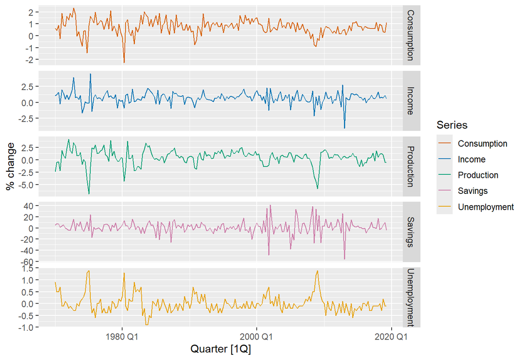

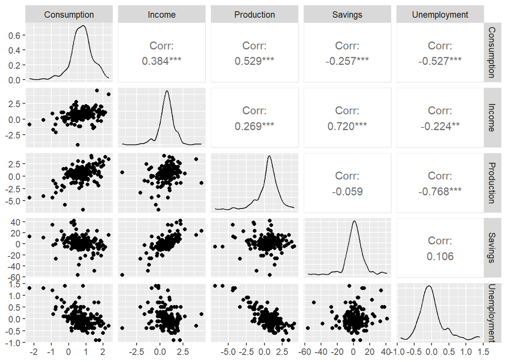

```r
us_change |> GGally::ggpairs(columns = 2:6)
```

There appears to be a strong positive linear relationship between Producion and Consumption, Savings and Income and a strong negative linear relationship between Unemployment and Consumption and Unemployment and Production.

We can then define the distance correlation:
$$\begin{align*}
\mathcal{R}(X, Y)
= \frac{\mathcal{V}^2(X,Y)}{\sqrt{\mathcal{V}^2(X,X)\mathcal{V}^2(Y,Y)}}
\end{align*}$$

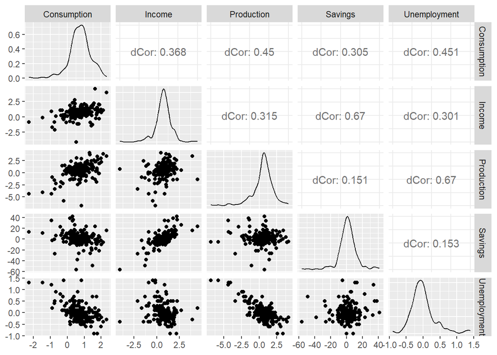

```r
library(energy)
library(GGally)

# Custom function for distance correlation
dcor_fun <- function(data, mapping) {
  x <- eval_data_col(data, mapping$x)
  y <- eval_data_col(data, mapping$y)
  dcor_val <- dcor(x, y)

  # Create text annotation
  ggally_text(
    label = paste("dCor:", round(dcor_val, 3)),
    mapping = aes(),
    xP = 0.5, yP = 0.5
  )
}

# # Create the plot
# ggpairs(your_data,
#         lower = list(continuous = "points"),
#         diag = list(continuous = "densityDiag"),
#         upper = list(continuous = dcor_fun))

us_change |> GGally::ggpairs(columns = 2:6,
                             lower = list(continuous = "points"),
                             diag = list(continuous = "densityDiag"),
                             upper = list(continuous = dcor_fun))
```

In this case there is no negative or positive correlation simply a number between 0 and 1 indicating the strength of the relationship between two variables. For instance, while the correlation between savings and production appears close to zero (-0.059), the distance correlation actually reveals some (nonlinear) relationship.

# 6. Lag Plots

## Example: Beer production

```r
new_production <- aus_production |>
  filter(year(Quarter) >= 1992)
new_production
```

```
## # A tsibble: 74 x 7 [1Q]
##    Quarter  Beer Tobacco Bricks Cement Electricity   Gas
##      <qtr> <dbl>   <dbl>  <dbl>  <dbl>       <dbl> <dbl>
##  1 1992 Q1   443    5777    383   1289       38332   117
##  2 1992 Q2   410    5853    404   1501       39774   151
##  3 1992 Q3   420    6416    446   1539       42246   175
##  4 1992 Q4   532    5825    420   1568       38498   129
##  5 1993 Q1   433    5724    394   1450       39460   116
##  6 1993 Q2   421    6036    462   1668       41356   149
##  7 1993 Q3   410    6570    475   1648       42949   163
##  8 1993 Q4   512    5675    443   1863       40974   138
##  9 1994 Q1   449    5311    421   1468       40162   127
## 10 1994 Q2   381    5717    475   1755       41199   159
## # ℹ 64 more rows
```

```r
new_production |> gg_lag(Beer, geom = "point")
```

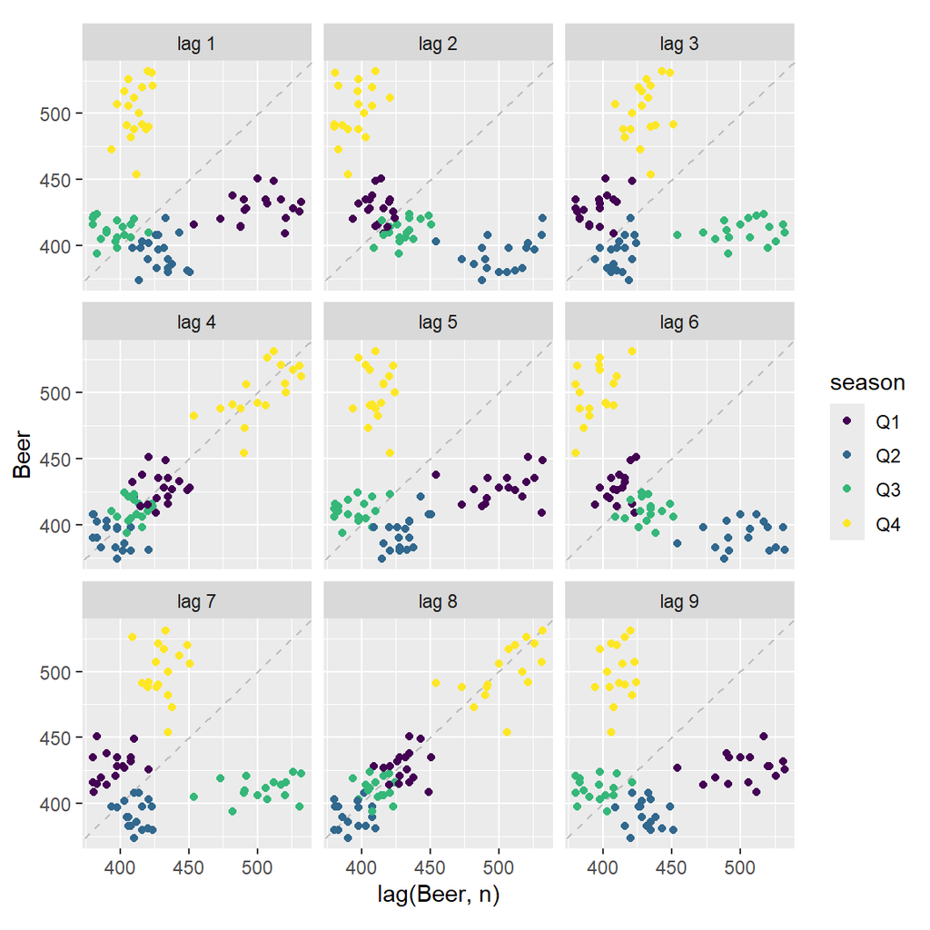

Each graph shows $Y_t$ plotted against $Y_{t-k}$ for different values of $k$. First plot plots $Y_t$ again $Y_{t-1}$, second plot $Y_t$ again $Y_{t-2}$ and so on. Note that for lag 4, we plot Q4 of this year against Q4 of the previous year (4 quarters lag). Since this data has strong seasonality (values in Q4 this year tend to be strongly related to values in Q4 of the previous year) we observe a strong relationship.

```r
new_production |> gg_lag(Beer)
```

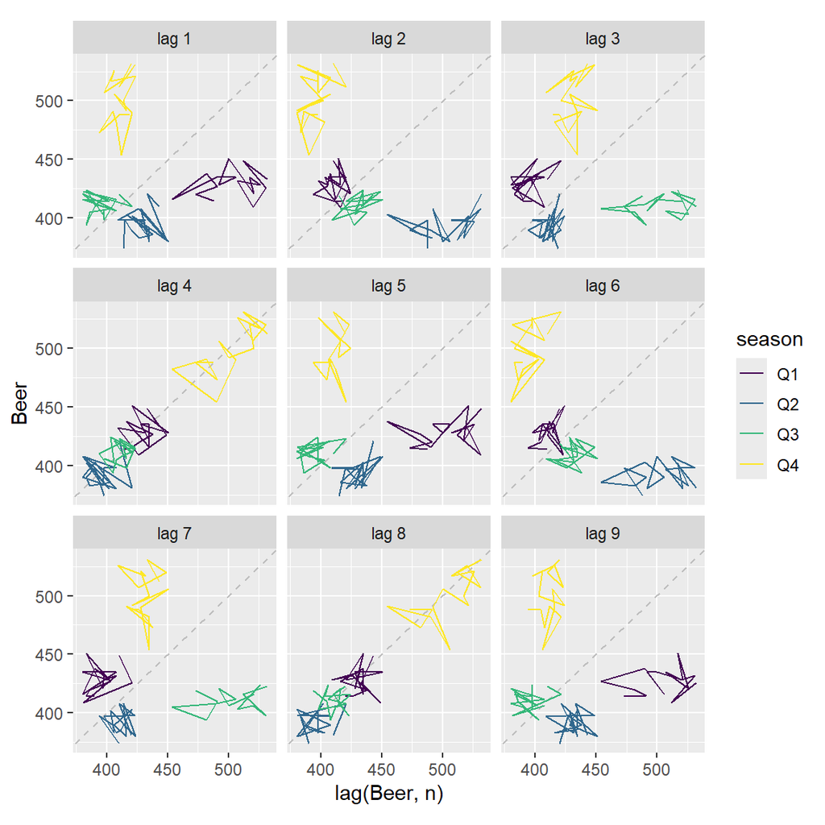

Each graph shows $Y_t$ plotted against $Y_{t-k}$ for different values of $k$. This time with lines instead of points, showing the time ordering. In this case, this doesn’t really add information.

# 7. Autocorrelation

One of the key tools to understand a time series.

```r
library(patchwork)
new_production <- aus_production |>
  filter(year(Quarter) >= 1992)
```

## Example: Beer production

```r
new_production |> gg_lag(Beer, geom = "point")
```

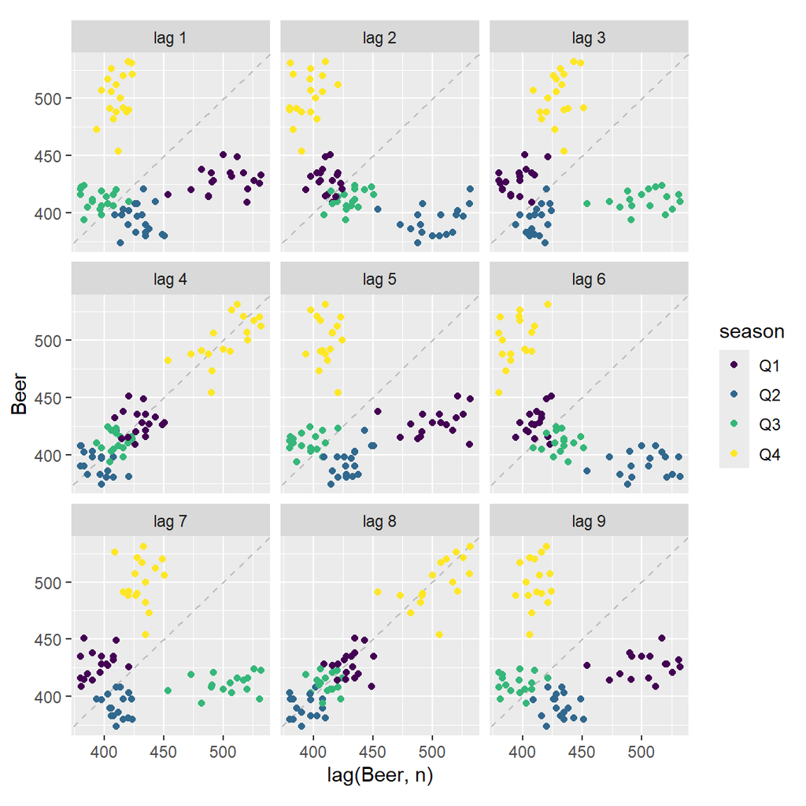

## Autocorrelation

Under weak stationarity the autocovariance, $\gamma(s,t) = \text{Cov}(Y_s, Y_t)$ only depence on the difference $h=|s-t|$. As such we shorten this to $\gamma(h)$ and similarly we denote the autocorrelation function as $\rho(h)$. They are then estimated as:

$$\begin{align*}
\hat{\gamma}(h) &= \frac{1}{T}\sum_{t=h+1}^T
(Y_t-\bar{Y})(Y_{t-h}-\bar{Y}) \\[0.cm]
\text{and}\qquad
\hat{\rho}(h) &= \hat{\gamma}(h)/\hat{\gamma}(0)
\end{align*}$$

- $\hat{\rho}(1)$ indicates how successive values of $Y_t$ relate to each other
- $\hat{\rho}(2)$ indicates how $Y_t$ values two periods apart relate to each other
- $\hat{\rho}(k)$ is the same as the sample correlation between $Y_t$ and $Y_{t-k}$.

Results for first 9 lags for beer data:

```r
# ACF function for the acf plot
new_production |> ACF(Beer, lag_max = 9)
```

```
## # A tsibble: 9 x 2 [1Q]
##        lag     acf
##   <cf_lag>   <dbl>
## 1       1Q -0.102
## 2       2Q -0.657
## 3       3Q -0.0603
## 4       4Q  0.869
## 5       5Q -0.0892
## 6       6Q -0.635
## 7       7Q -0.0542
## 8       8Q  0.832
## 9       9Q -0.108
```

Results for first 9 lags for beer data:

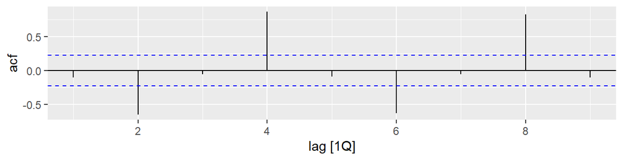

```r
new_production |> ACF(Beer, lag_max = 9) |> autoplot()
```

Plot of the correlation for different lags, with confidence bands. These confidence bands are not simultaneous, so even if all lags are truly zero, we would expect around $5\%$ of values to fall outside. Again we see the strong correlation at lag 4 and 8, showing the seasonal pattern.

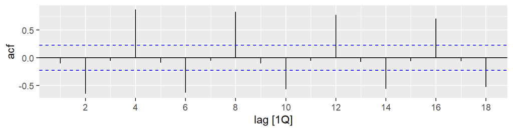

```r
new_production |> ACF(Beer) |> autoplot()
```

- $\hat{\rho}(4)$ higher than for the other lags due to **the seasonal pattern in the data**: peaks tend to be **4 quarters** apart and troughs tend to be **4 quarters** apart.
- $\hat{\rho}(2)$ is more negative than for the other lags because troughs tend to be 2 quarters behind peaks.

## US retail trade employment

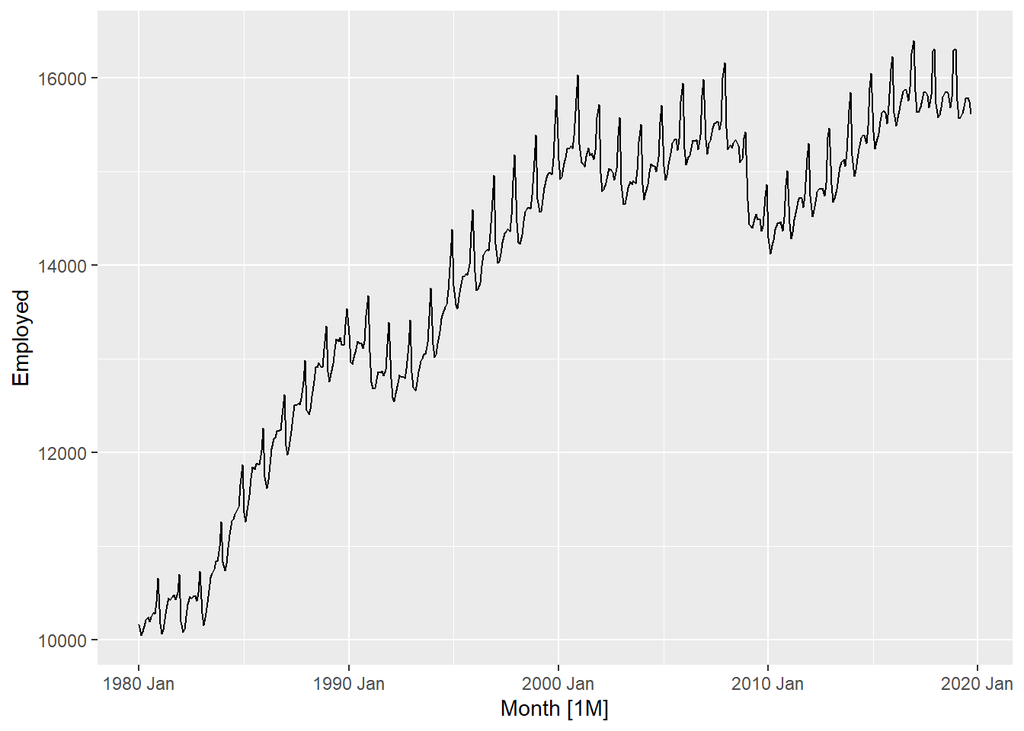

```r
retail <- us_employment |>
  filter(Title == "Retail Trade", year(Month) >= 1980)
retail |> autoplot(Employed)
```

This data is both trending and seasonal.

## US retail trade employment

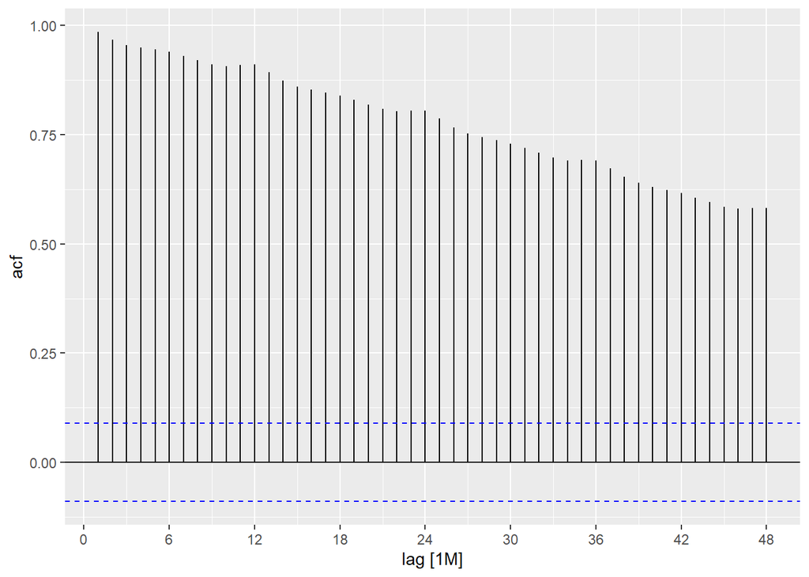

```r
retail |>
  ACF(Employed, lag_max = 48) |>
  autoplot()
```

Here all autocorrelations are strongly positive because of the trend. There is also a small peak around the seasonal multiples (12, 24). This is the effect of seasonality.

## Google stock price

```r
google_2015 <- gafa_stock |>
  filter(Symbol == "GOOG", year(Date) == 2015) |>
  select(Date, Close)
google_2015
```

```
## # A tsibble: 252 x 2 [!]
##    Date       Close
##    <date>     <dbl>
##  1 2015-01-02  522.
##  2 2015-01-05  511.
##  3 2015-01-06  499.
##  4 2015-01-07  498.
##  5 2015-01-08  500.
##  6 2015-01-09  493.
##  7 2015-01-12  490.
##  8 2015-01-13  493.
##  9 2015-01-14  498.
## 10 2015-01-15  499.
## # ℹ 242 more rows
```

Note the exclamation mark above, it means the data is not regularly spaced (simply because trading does not happen every day).

## Google stock price

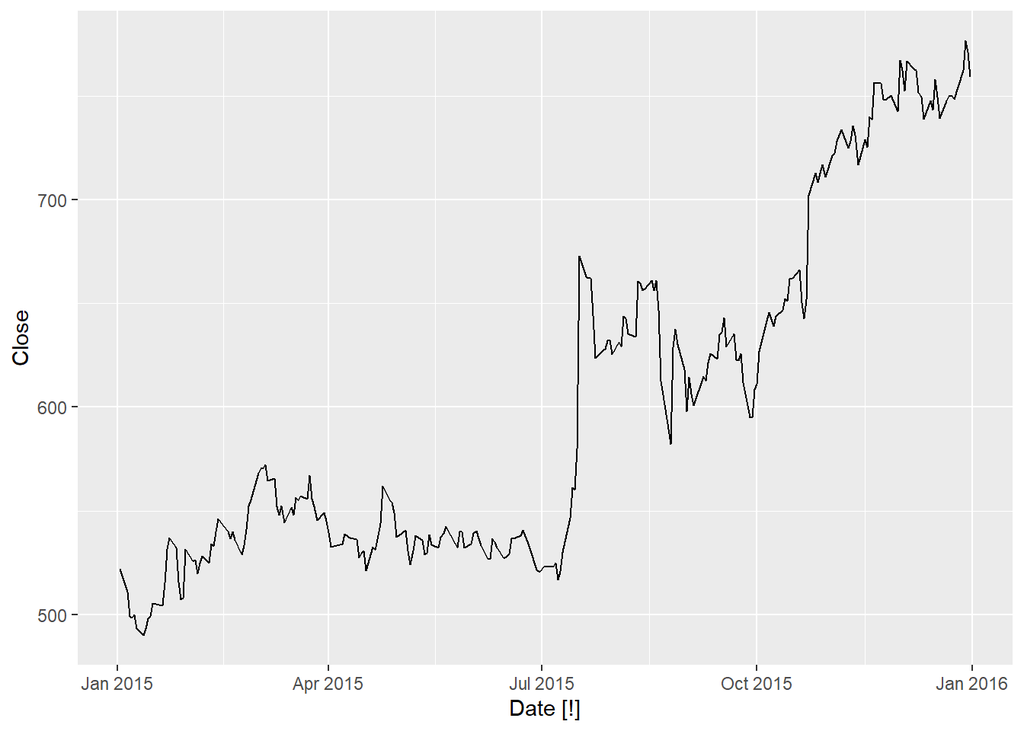

```r
google_2015 |> autoplot(Close)
```

We see some general upward trend in this series (approximately).

## Google stock price

```r
google_2015 |>
  ACF(Close, lag_max = 100)
```

```
## # A tsibble: 100 x 2 [1]
##         lag   acf
##    <cf_lag> <dbl>
##  1        1 0.982
##  2        2 0.959
##  3        3 0.937
##  4        4 0.918
##  5        5 0.901
##  6        6 0.883
##  7        7 0.865
##  8        8 0.849
##  9        9 0.834
## 10       10 0.818
## # ℹ 90 more rows
```

## Google stock price

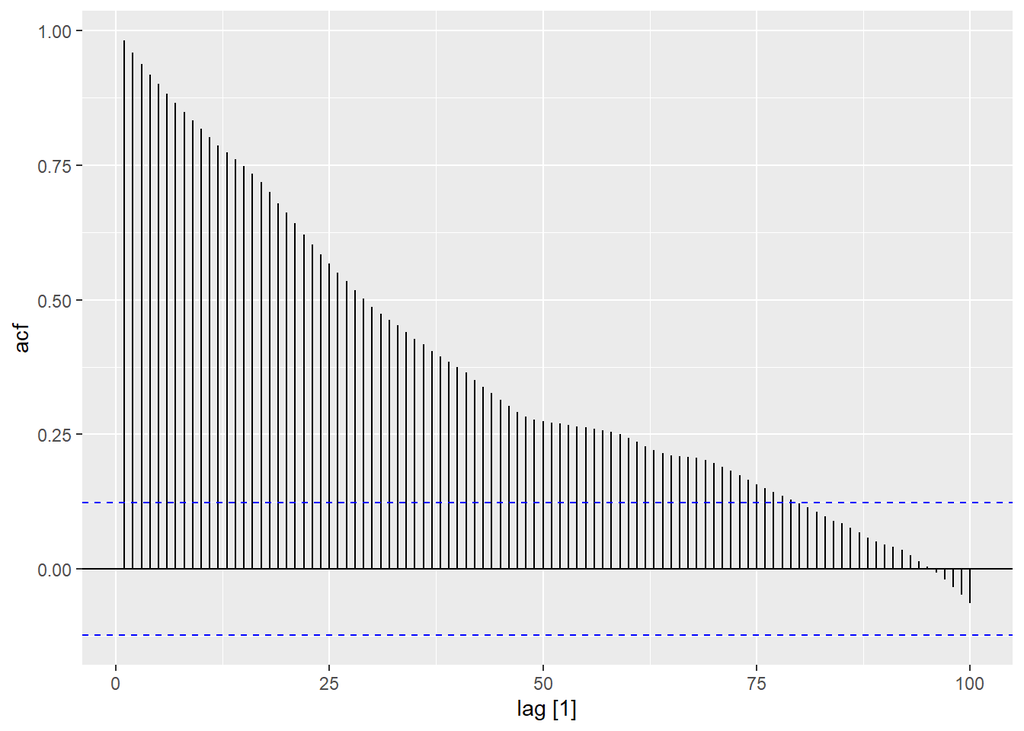

```r
google_2015 |>
  ACF(Close, lag_max = 100) |>
  autoplot()
```

Again the high positive autocorrelations indicate the trend.

Since autocorrelations only pick up on linear dependencies, generalizations are useful. In particular we will study the distance autcorrelation $\mathcal{R}(Y_{t}, Y_{t-h})$, which is simply the distance correlation between $Y_t$ and $Y_{t-h}$.

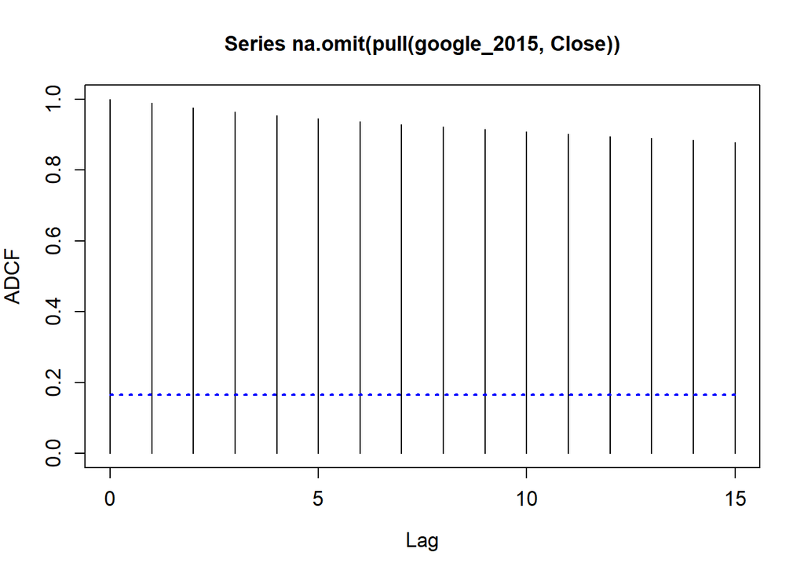

```
## $ADCF
##    lag 0 lag 1 lag 2 lag 3 lag 4 lag 5 lag 6 lag 7 lag 8 lag 9 lag 10
##        1 0.989 0.976 0.964 0.954 0.945 0.937 0.929 0.922 0.915  0.909
##    lag 11 lag 12 lag 13 lag 14 lag 15
##     0.902  0.896   0.89  0.885  0.878
##
## $bootMethod
## [1] "Wild Bootstrap"
##
## $critical.values
## [1] 0.167
```

```r
library(patchwork)
library(dCovTS)
library(doSNOW)
google_2015 |>
     pull(Close) |>
     na.omit() |>
     ADCFplot()
```

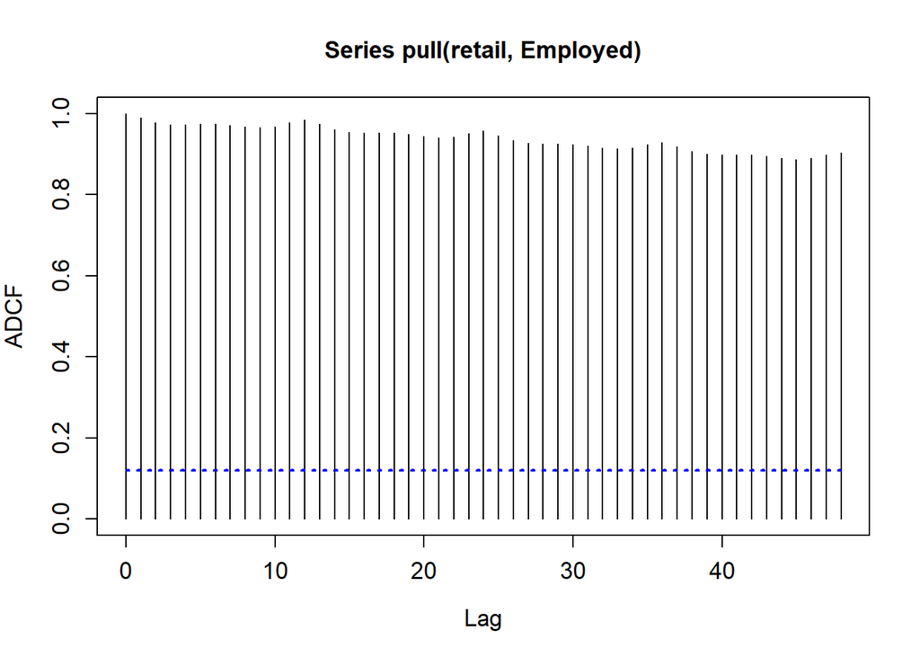

```
## $ADCF
##    lag 0 lag 1 lag 2 lag 3 lag 4 lag 5 lag 6 lag 7 lag 8 lag 9 lag 10
##        1  0.99 0.978 0.973 0.973 0.974 0.975 0.972 0.968 0.965  0.968
##    lag 11 lag 12 lag 13 lag 14 lag 15 lag 16 lag 17 lag 18 lag 19 lag 20
##     0.978  0.985  0.974  0.961  0.954  0.953  0.953  0.953  0.949  0.944
##    lag 21 lag 22 lag 23 lag 24 lag 25 lag 26 lag 27 lag 28 lag 29 lag 30
##     0.941  0.943  0.951  0.957  0.947  0.934  0.927  0.926  0.926  0.925
##    lag 31 lag 32 lag 33 lag 34 lag 35 lag 36 lag 37 lag 38 lag 39 lag 40
##     0.921  0.916  0.913  0.915  0.923  0.929  0.919  0.907  0.901  0.899
##    lag 41 lag 42 lag 43 lag 44 lag 45 lag 46 lag 47 lag 48
##     0.899  0.898  0.894   0.89  0.887   0.89  0.898  0.904
##
## $bootMethod
## [1] "Wild Bootstrap"
##
## $critical.values
## [1] 0.121
```

```r
retail |>
  pull(Employed) |>
  ADCFplot(MaxLag=48)
```

# 8. White Noise

## Example: White noise

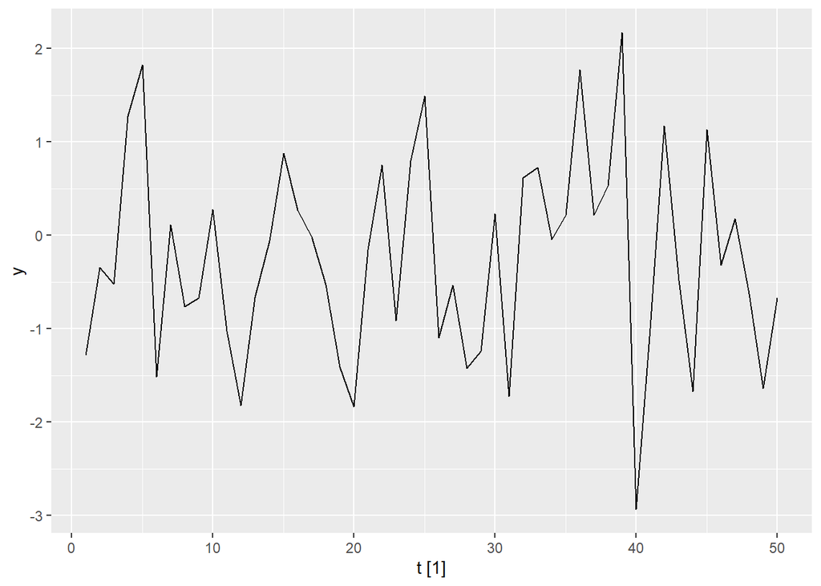

```r
set.seed(30)
wn <- tsibble(t = 1:50, y = rnorm(50), index = t)
wn |> autoplot(y)
```

White noise data is uncorrelated across time with zero mean and constant variance. (Technically, we require independence as well.) The marginal distribution $P_t$ is however not known in general.

```
## # A tsibble: 16 x 2 [1]
##         lag     acf
##    <cf_lag>   <dbl>
##  1        1  0.0138
##  2        2 -0.163
##  3        3  0.163
##  4        4 -0.259
##  5        5 -0.198
##  6        6  0.0642
##  7        7 -0.139
##  8        8 -0.0316
##  9        9  0.199
## 10       10 -0.0240
## 11       11  0.0860
## 12       12  0.0790
## 13       13 -0.144
## 14       14 -0.0154
## 15       15 -0.0702
## 16       16 -0.266
```

| $r_{1}$ | $r_{2}$ | $r_{3}$ | $r_{4}$ | $r_{5}$ | $r_{6}$ | $r_{7}$ | $r_{8}$ | $r_{9}$ | $r_{10}$ |
| --- | --- | --- | --- | --- | --- | --- | --- | --- | --- |
| 0.014 | -0.163 | 0.163 | -0.259 | -0.198 | 0.064 | -0.139 | -0.032 | 0.199 | -0.024 |

[figure not shown]

```r
wn |> ACF(y)
```

- Sample autocorrelations for white noise series.
- Expect each autocorrelation to be close to zero.
- Blue lines show 95% critical values.

## Sampling distribution of autocorrelations

Sampling distribution of $\hat{\rho}(k)$ for white noise data is asymptotically N(0,$1/T$).

In contrast the distance autocorrelation approach uses a bootstrap scheme to get confidence bands. Thus as soon as 1 lag is above the line, independence can be rejected:

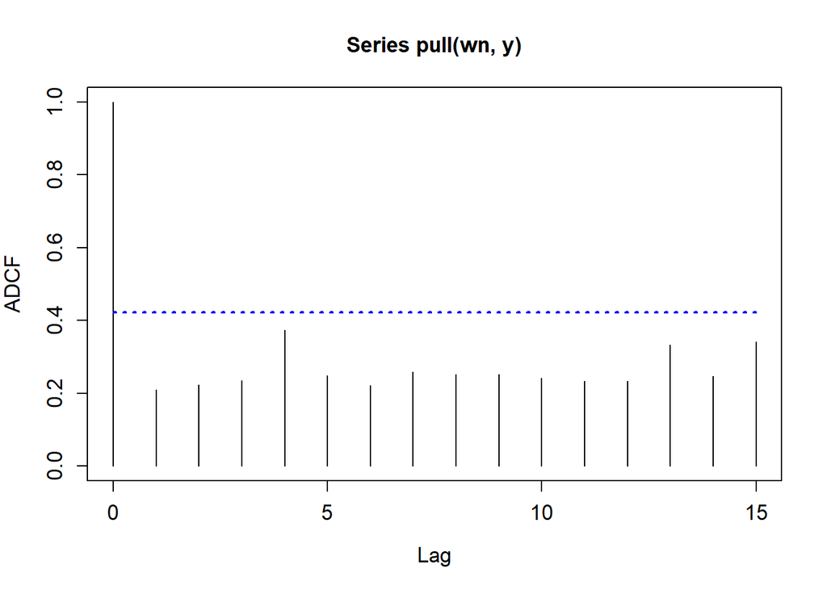

```
## $ADCF
##    lag 0 lag 1 lag 2 lag 3 lag 4 lag 5 lag 6 lag 7 lag 8 lag 9 lag 10
##        1  0.21 0.223 0.235 0.374 0.248 0.222 0.258 0.253 0.252  0.243
##    lag 11 lag 12 lag 13 lag 14 lag 15
##     0.233  0.233  0.333  0.247  0.341
##
## $bootMethod
## [1] "Wild Bootstrap"
##
## $critical.values
## [1] 0.422
```

```r
wn |>
  pull(y) |>
  ADCFplot()
```

## Example: Pigs slaughtered

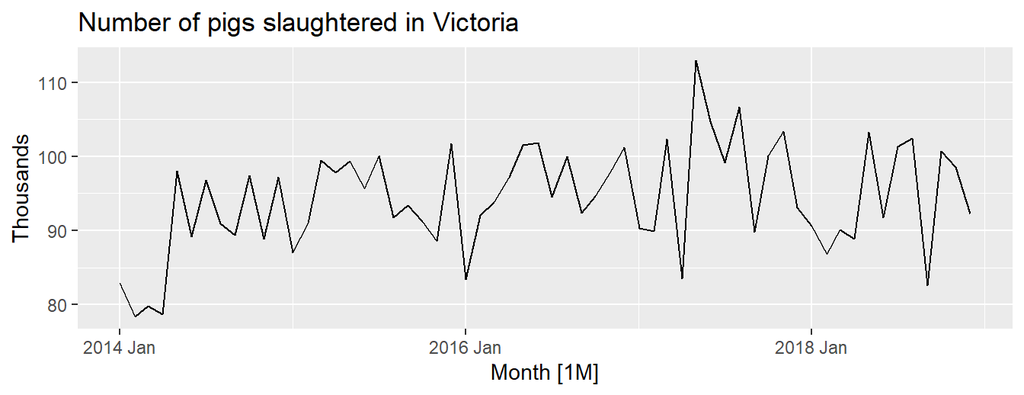

```r
pigs <- aus_livestock |>
  filter(State == "Victoria", Animal == "Pigs", year(Month) >= 2014)
pigs |> autoplot(Count / 1e3) +
  labs(y = "Thousands", title = "Number of pigs slaughtered in Victoria")
```

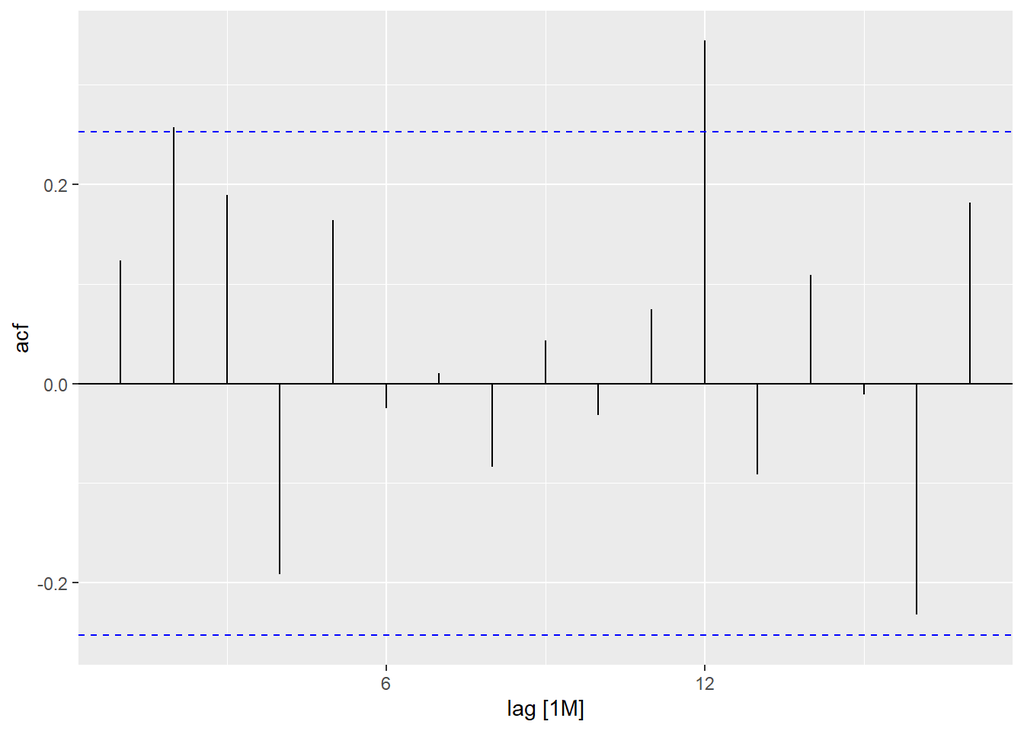

```r
pigs |>
  ACF(Count) |>
  autoplot()
```

Monthly total number of pigs slaughtered in the state of Victoria, Australia, from January 2014 through December 2018 (Source: Australian Bureau of Statistics.)

- Difficult to detect pattern in time plot.
- ACF shows significant autocorrelation for lag 2 and 12.
- Indicate some slight seasonality.

These show the series is **not a white noise series**.

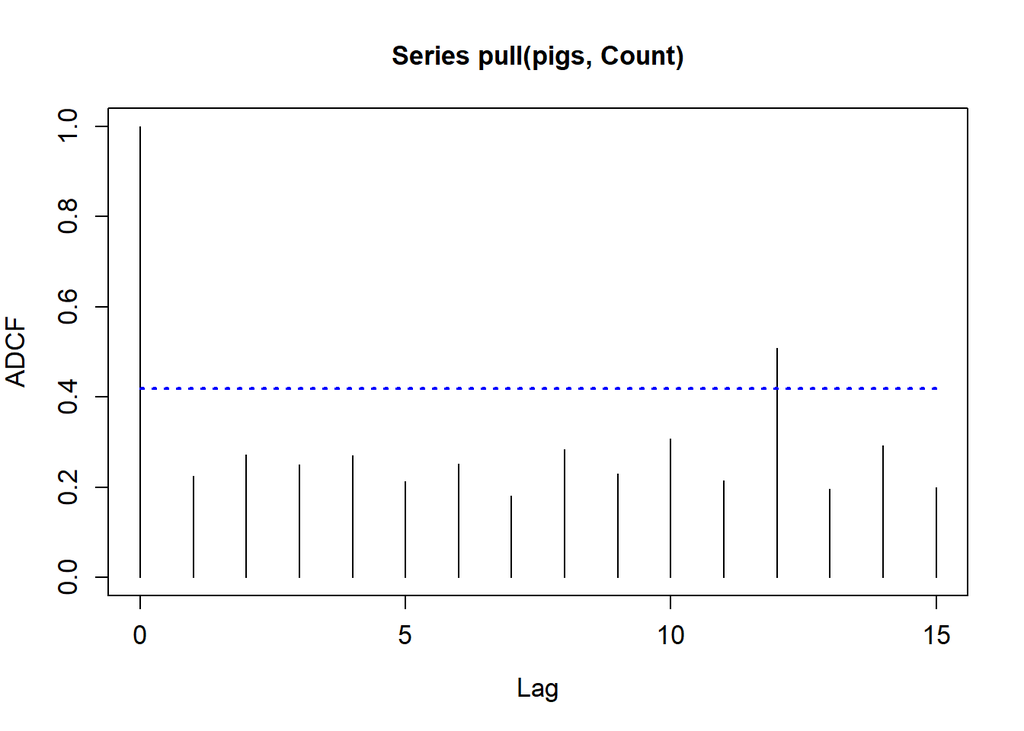

```
## $ADCF
##    lag 0 lag 1 lag 2 lag 3 lag 4 lag 5 lag 6 lag 7 lag 8 lag 9 lag 10
##        1 0.224 0.272  0.25 0.271 0.214 0.252 0.181 0.284  0.23  0.308
##    lag 11 lag 12 lag 13 lag 14 lag 15
##     0.216  0.509  0.197  0.292  0.199
##
## $bootMethod
## [1] "Wild Bootstrap"
##
## $critical.values
## [1] 0.42
```

```r
pigs |>
  pull(Count) |>
  ADCFplot()
```

Again we see a significant spike (even in the uniform confidence bands) at lag 12, indicating seasonality.